# 310657002_統計碩_林奕勳_hw03

```r
library(survival)
library(nnet)
library(MASS)
```

define function for remove missing value

```r
remove_miss_value = function(data)
{
  if (sum(is.na(data)) != 0)
  {
    miss_value_index = c()
    for(i in 1:dim(data)[2])
    {
       miss_value_index = c(miss_value_index,which(is.na(data[,i])==1))
    }
    data = data[-miss_value_index,]
  }

  return (data)
}
```

# read data

```r
data_1 = read.table('http://ghuang.stat.nctu.edu.tw/course/biostat21/files/data/HEALTH.TXT', header=TRUE)
data_2 = read.table('http://ghuang.stat.nctu.edu.tw/course/biostat21/files/data/HOSPITAL.TXT', header=TRUE)
data_3 = read.table('http://ghuang.stat.nctu.edu.tw/course/biostat21/files/data/MES.TXT' , header=TRUE)
```

# Q1

```r
data_1 = remove_miss_value(data_1)
Q1_a_crude = glm(BH ~ GENDER , data = data_1 , family='binomial')
cat('the crude odds ratio is coefficient of GENDER' , exp(Q1_a_crude$coefficients[2]) ,'\n')
```

```
## the crude odds ratio is coefficient of GENDER 0.6463786
```

```r
cat('95% crude odds ratio CI is ' , exp(confint(Q1_a_crude,level=0.95 )[2,]),'\n')
```

```
## 95% crude odds ratio CI is  0.4593326 0.9074157
```

```r
Q1_a_adj_sex = glm(BH ~ GENDER+AGE , data = data_1 , family='binomial')
cat('the odds ratio is coefficient of GENDER' , exp(Q1_a_adj_sex$coefficients[2]) ,'\n')
```

```
## the odds ratio is coefficient of GENDER 0.6421985
```

```r
cat('95% GENDER odds ratio CI with adjust AGE is ' , exp(confint(Q1_a_adj_sex,level=0.95 ))[2,],'\n')
```

```
## 95% GENDER odds ratio CI with adjust AGE is  0.4554816 0.9031813
```

```r
summary(Q1_a_adj_sex)
```

```
##
## Call:
## glm(formula = BH ~ GENDER + AGE, family = "binomial", data = data_1)
##
## Deviance Residuals:
##     Min       1Q   Median       3Q      Max
## -1.3018  -1.0682  -0.9212   1.2272   1.6342
##
## Coefficients:
##             Estimate Std. Error z value Pr(>|z|)
## (Intercept)  0.31417    0.19168   1.639   0.1012
## GENDER      -0.44286    0.17452  -2.538   0.0112 *
## AGE         -0.03246    0.01373  -2.365   0.0180 *
## ---
## Signif. codes:  0 '***' 0.001 '**' 0.01 '*' 0.05 '.' 0.1 ' ' 1
##
## (Dispersion parameter for binomial family taken to be 1)
##
##     Null deviance: 751.23  on 547  degrees of freedom
## Residual deviance: 739.13  on 545  degrees of freedom
## AIC: 745.13
##
## Number of Fisher Scoring iterations: 4
```

```r
Q1_b_age_dummy1 = rep(0 , dim(data_1)[1])
Q1_b_age_dummy2 = rep(0 , dim(data_1)[1])
Q1_b_age_dummy3 = rep(0 , dim(data_1)[1])
Q1_b_age_dummy4 = rep(0 , dim(data_1)[1])
Q1_b_age_dummy1[data_1['AGE'] <= 7] = 1
Q1_b_age_dummy2[7<data_1['AGE']&data_1['AGE']<=11] = 1
Q1_b_age_dummy3[11<data_1['AGE']&data_1['AGE']<=15] = 1
Q1_b_age_dummy4[data_1['AGE']>15] = 1
Gender = data_1$GENDER

data_1_copy = data_1
data_1_copy['AGE_stratum'] = 1
data_1_copy[7<data_1_copy['AGE']&data_1_copy['AGE']<=11,'AGE_stratum'] = 2
data_1_copy[11<data_1_copy['AGE']&data_1_copy['AGE']<=15,'AGE_stratum'] = 3
data_1_copy[data_1_copy['AGE']>15,'AGE_stratum'] = 4

logistic_dummy_for_age = glm(data_1$BH ~ Gender+Q1_b_age_dummy2+Q1_b_age_dummy3+Q1_b_age_dummy4 , family='binomial')
logistic_stratum_for_age = glm(BH ~ Gender+AGE_stratum , data = data_1_copy , family='binomial')

summary(logistic_dummy_for_age)
```

```
##
## Call:
## glm(formula = data_1$BH ~ Gender + Q1_b_age_dummy2 + Q1_b_age_dummy3 +
##     Q1_b_age_dummy4, family = "binomial")
##
## Deviance Residuals:
##     Min       1Q   Median       3Q      Max
## -1.2555  -1.0657  -0.8375   1.2679   1.5608
##
## Coefficients:
##                  Estimate Std. Error z value Pr(>|z|)
## (Intercept)      0.181806   0.173016   1.051   0.2933
## Gender          -0.450411   0.175819  -2.562   0.0104 *
## Q1_b_age_dummy2 -0.006408   0.234032  -0.027   0.9782
## Q1_b_age_dummy3 -0.392083   0.238982  -1.641   0.1009
## Q1_b_age_dummy4 -0.598754   0.249453  -2.400   0.0164 *
## ---
## Signif. codes:  0 '***' 0.001 '**' 0.01 '*' 0.05 '.' 0.1 ' ' 1
##
## (Dispersion parameter for binomial family taken to be 1)
##
##     Null deviance: 751.23  on 547  degrees of freedom
## Residual deviance: 736.56  on 543  degrees of freedom
## AIC: 746.56
##
## Number of Fisher Scoring iterations: 4
```

```r
summary(logistic_stratum_for_age)
```

```
##
## Call:
## glm(formula = BH ~ Gender + AGE_stratum, family = "binomial",
##     data = data_1_copy)
##
## Deviance Residuals:
##     Min       1Q   Median       3Q      Max
## -1.2810  -1.0960  -0.8514   1.2557   1.5431
##
## Coefficients:
##             Estimate Std. Error z value Pr(>|z|)
## (Intercept)  0.45140    0.21769   2.074  0.03812 *
## Gender      -0.43482    0.17475  -2.488  0.01284 *
## AGE_stratum -0.21118    0.07798  -2.708  0.00677 **
## ---
## Signif. codes:  0 '***' 0.001 '**' 0.01 '*' 0.05 '.' 0.1 ' ' 1
##
## (Dispersion parameter for binomial family taken to be 1)
##
##     Null deviance: 751.23  on 547  degrees of freedom
## Residual deviance: 737.43  on 545  degrees of freedom
## AIC: 743.43
##
## Number of Fisher Scoring iterations: 4
```

```r
# model by (b)
cat('95% stratum variable odds ratio CI with adjust gender is ' , exp(confint(logistic_stratum_for_age,level=0.95 )[2,]),'\n')
```

```
## 95% stratum variable odds ratio CI with adjust gender is  0.4589726 0.9109224
```

```r
fisher.test(table(Gender,data_1$BH))
```

```
##
##  Fisher's Exact Test for Count Data
##
## data:  table(Gender, data_1$BH)
## p-value = 0.01258
## alternative hypothesis: true odds ratio is not equal to 1
## 95 percent confidence interval:
##  0.4532729 0.9213363
## sample estimates:
## odds ratio
##  0.6469128
```

```r
cat('use 2by2 table find that the 95% CI is 0.4532729 , 0.9213363')
```

```
## use 2by2 table find that the 95% CI is 0.4532729 , 0.9213363
```

1. if use continuous variable with AGE , then need assumption is linear with BH , (i.e every one unit increase in AGE is constant when holding all other variables are fixed.) AGE and Gender have not interaction ,and Independence
2. if use stratum variable with AGE , then need assumption group is linear with BH (age not need linear) , AGE and Gender have not interaction, and Independence
3. I think use stratum is more appropriate than continuous , since AIC of stratum is smaller than continuous and AGE is more significance (i.e p-value is smaller), and Independence

```r
cat('the odds ratio  coefficien of AGE(continuous)' , exp(Q1_a_adj_sex$coefficients[3]) ,'\n')
```

```
## the odds ratio  coefficien of AGE(continuous) 0.9680644
```

mean is one unit increase in AGE odds ratio will increase 0.9680644 when holding all other variables are fixed

and p-value is 0.0180 for AGE(continuous)

```r
cat('the odds ratio is coefficien of AGE(stratum)' , exp(logistic_stratum_for_age$coefficients[3]) ,'\n')
```

```
## the odds ratio is coefficien of AGE(stratum) 0.8096271
```

mean is one unit increase in age-stratum odds ratio will increase 0.8096271 when holding all other variables are fixed

and p-value is 0.00677 for AGE(stratum)

```r
logistic_stratum_for_age_GHb = glm(BH ~ Gender+AGE_stratum+GHb , data = data_1_copy , family='binomial')
summary(logistic_stratum_for_age)
```

```
##
## Call:
## glm(formula = BH ~ Gender + AGE_stratum, family = "binomial",
##     data = data_1_copy)
##
## Deviance Residuals:
##     Min       1Q   Median       3Q      Max
## -1.2810  -1.0960  -0.8514   1.2557   1.5431
##
## Coefficients:
##             Estimate Std. Error z value Pr(>|z|)
## (Intercept)  0.45140    0.21769   2.074  0.03812 *
## Gender      -0.43482    0.17475  -2.488  0.01284 *
## AGE_stratum -0.21118    0.07798  -2.708  0.00677 **
## ---
## Signif. codes:  0 '***' 0.001 '**' 0.01 '*' 0.05 '.' 0.1 ' ' 1
##
## (Dispersion parameter for binomial family taken to be 1)
##
##     Null deviance: 751.23  on 547  degrees of freedom
## Residual deviance: 737.43  on 545  degrees of freedom
## AIC: 743.43
##
## Number of Fisher Scoring iterations: 4
```

```r
summary(logistic_stratum_for_age_GHb)
```

```
##
## Call:
## glm(formula = BH ~ Gender + AGE_stratum + GHb, family = "binomial",
##     data = data_1_copy)
##
## Deviance Residuals:
##    Min      1Q  Median      3Q     Max
## -1.524  -1.057  -0.804   1.202   2.031
##
## Coefficients:
##             Estimate Std. Error z value Pr(>|z|)
## (Intercept)  2.36179    0.55919   4.224  2.4e-05 ***
## Gender      -0.44396    0.17716  -2.506 0.012213 *
## AGE_stratum -0.23694    0.07918  -2.993 0.002766 **
## GHb         -0.16885    0.04514  -3.740 0.000184 ***
## ---
## Signif. codes:  0 '***' 0.001 '**' 0.01 '*' 0.05 '.' 0.1 ' ' 1
##
## (Dispersion parameter for binomial family taken to be 1)
##
##     Null deviance: 751.23  on 547  degrees of freedom
## Residual deviance: 722.32  on 544  degrees of freedom
## AIC: 730.32
##
## Number of Fisher Scoring iterations: 4
```

I think GHb is not confounding effect for AGE and Gender , since coefficient is similar

```r
logistic_interaction = glm(BH ~ Gender+AGE_stratum+GHb+Gender:GHb, data = data_1_copy , family='binomial')
logistic = glm(BH ~ Gender+AGE_stratum+GHb, data = data_1_copy , family='binomial')

summary(logistic_interaction)
```

```
##
## Call:
## glm(formula = BH ~ Gender + AGE_stratum + GHb + Gender:GHb, family = "binomial",
##     data = data_1_copy)
##
## Deviance Residuals:
##    Min      1Q  Median      3Q     Max
## -1.512  -1.059  -0.800   1.204   2.073
##
## Coefficients:
##             Estimate Std. Error z value Pr(>|z|)
## (Intercept)  2.25786    0.69834   3.233  0.00122 **
## Gender      -0.20224    0.99811  -0.203  0.83943
## AGE_stratum -0.23739    0.07916  -2.999  0.00271 **
## GHb         -0.15923    0.05948  -2.677  0.00743 **
## Gender:GHb  -0.02228    0.09058  -0.246  0.80567
## ---
## Signif. codes:  0 '***' 0.001 '**' 0.01 '*' 0.05 '.' 0.1 ' ' 1
##
## (Dispersion parameter for binomial family taken to be 1)
##
##     Null deviance: 751.23  on 547  degrees of freedom
## Residual deviance: 722.26  on 543  degrees of freedom
## AIC: 732.26
##
## Number of Fisher Scoring iterations: 4
```

```r
summary(logistic)
```

```
##
## Call:
## glm(formula = BH ~ Gender + AGE_stratum + GHb, family = "binomial",
##     data = data_1_copy)
##
## Deviance Residuals:
##    Min      1Q  Median      3Q     Max
## -1.524  -1.057  -0.804   1.202   2.031
##
## Coefficients:
##             Estimate Std. Error z value Pr(>|z|)
## (Intercept)  2.36179    0.55919   4.224  2.4e-05 ***
## Gender      -0.44396    0.17716  -2.506 0.012213 *
## AGE_stratum -0.23694    0.07918  -2.993 0.002766 **
## GHb         -0.16885    0.04514  -3.740 0.000184 ***
## ---
## Signif. codes:  0 '***' 0.001 '**' 0.01 '*' 0.05 '.' 0.1 ' ' 1
##
## (Dispersion parameter for binomial family taken to be 1)
##
##     Null deviance: 751.23  on 547  degrees of freedom
## Residual deviance: 722.32  on 544  degrees of freedom
## AIC: 730.32
##
## Number of Fisher Scoring iterations: 4
```

Interpret with interaction

1. GHb increase one unit , log odds ratio decrease (0.15923) for Gender is male(Gender=0) when other variables are fixed
2. GHb increase one unit , log odds ratio decrease (0.15923+0.02228) for Gender is female(Gender=1) when other variables are fixed
3. male(Gender=0) is more than female log odds ratio (0.20224+0.02228) when other variables are fixed

Interpret without interaction

1. male(Gender=0) odds ratio is more than female log odds ratio (0.44396) when other variables are fixed
2. GHb increase one unit ,log odds ratio decrease (0.16885) when other variables are fixed

# Q2

```r
data_2 = remove_miss_value(data_2)
data_2_copy = data_2
data_2_table = data.frame('Gender'=c(0,0,0,0,1,1,1,1),
                          'HEALTH'=c(1,2,3,4,1,2,3,4),
                          'HEALTH2'=c(0,1,0,0,0,1,0,0),
                          'HEALTH3'=c(0,0,1,0,0,0,1,0),
                          'HEALTH4'=c(0,0,0,1,0,0,0,1),
                          'hospitalization'=c(25,38,10,4,25,59,19,3),
                          'observation'=c(530,514,81,9,381,582,93,10))
data_2_table['no_hospitalization'] = data_2_table['observation'] - data_2_table['hospitalization']
HEALTH2 = rep(0,dim(data_2)[1])
HEALTH3 = rep(0,dim(data_2)[1])
HEALTH4 = rep(0,dim(data_2)[1])
HEALTH2[data_2['HEALTH']==2]=1
HEALTH3[data_2['HEALTH']==3]=1
HEALTH4[data_2['HEALTH']==4]=1
data_2_copy['HEALTH2'] = HEALTH2
data_2_copy['HEALTH3'] = HEALTH3
data_2_copy['HEALTH4'] = HEALTH4
```

```r
# goodness-of-fit for group data
# saturated model
logistic_Q2_a_saturated_model = glm(cbind(hospitalization,no_hospitalization)~Gender+HEALTH2+HEALTH3+HEALTH4+Gender:HEALTH2+Gender:HEALTH3+Gender:HEALTH4,data=data_2_table,family='binomial')

estimated  = 1/(1+exp(-predict(logistic_Q2_a_saturated_model,data_2_table[,c(1,3,4,5)])))
estimated = data.frame('estimated'=estimated)
observed  = data_2_table['hospitalization']/data_2_table['observation']
names(observed) = 'observed'
Q2_a_ans = data.frame(estimated,observed)
Q2_a_ans
```

```
##    estimated   observed
## 1 0.04716981 0.04716981
## 2 0.07392996 0.07392996
## 3 0.12345679 0.12345679
## 4 0.44444444 0.44444444
## 5 0.06561680 0.06561680
## 6 0.10137457 0.10137457
## 7 0.20430108 0.20430108
## 8 0.30000000 0.30000000
```

They are the same as the observed probabilities (it is obvious , since we use saturated model)

```r
# method one
Model_1 = glm(cbind(hospitalization,no_hospitalization)~Gender+HEALTH2+HEALTH3+HEALTH4,data=data_2_table,family='binomial')
Model_2 = glm(cbind(hospitalization,no_hospitalization)~Gender+HEALTH,data=data_2_table,family='binomial')
Model_3 = glm(cbind(hospitalization,no_hospitalization)~Gender+HEALTH+Gender:HEALTH,data=data_2_table,family='binomial')

diff_deviance = summary(Model_2)$deviance - summary(Model_3)$deviance
pchisq(diff_deviance, df=1,lower.tail = F)
```

```
## [1] 0.918857
```

I compare Model_2 vs Model_3 since p-value > 0.05 do not reject $H_0$ (i.e interaction term = 0) , so Model_2 is more helpful than Model_3 , and I compare Model_2 vs Model_1 can not use likelihood ratio tests , I think that HEALTH is ordinal data so use stratum variable(Label Encoding) is appropriate so Model_2 is most helpful in predicting HOSP

I set intercept model is baseline , compare with three models.

```r
# method two
Model_intercept = glm(cbind(hospitalization,no_hospitalization)~1,data=data_2_table,family='binomial')

diff_deviance = summary(Model_intercept)$deviance - summary(Model_1)$deviance
pchisq(diff_deviance, df=3,lower.tail = F)
```

```
## [1] 7.240745e-09
```

```r
diff_deviance = summary(Model_intercept)$deviance - summary(Model_2)$deviance
pchisq(diff_deviance, df=1,lower.tail = F)
```

```
## [1] 4.075043e-10
```

```r
diff_deviance = summary(Model_intercept)$deviance - summary(Model_3)$deviance
pchisq(diff_deviance, df=2,lower.tail = F)
```

```
## [1] 3.253689e-09
```

and find that model_2 is most significant (p-value is smallest) , have same result with method one

```r
cat('saturated model deviance is ',logistic_Q2_a_saturated_model$deviance,'\n')
```

```
## saturated model deviance is  5.253575e-13
```

```r
cat(' model_1 deviance is ',Model_1$deviance,'\n')
```

```
##  model_1 deviance is  1.391834
```

```r
cat(' model_2 deviance is ',Model_2$deviance,'\n')
```

```
##  model_2 deviance is  3.106572
```

```r
cat(' model_3 deviance is ',Model_3$deviance,'\n')
```

```
##  model_3 deviance is  3.096193
```

```r
# goodness-of-fit test  for saturated model with model 1
diff_deviance = summary(Model_1)$deviance - summary(logistic_Q2_a_saturated_model)$deviance
pchisq(diff_deviance, df=3,lower.tail = F)
```

```
## [1] 0.7074501
```

```r
# goodness-of-fit test  for model 2 with model 3
diff_deviance = summary(Model_2)$deviance - summary(Model_3)$deviance
pchisq(diff_deviance, df=1,lower.tail = F)
```

```
## [1] 0.918857
```

no matter dummy variable or stratum variable are good fit to the data(i.e three models provides a significantly good fit to the data) , since goodness-of-fit tests tell about no interactions between HEALTH (or HEALTH dummy variables) and GENDER (i.e no interaction model fits the observed data well)

```r
data_2_table_copy = data_2_table
names(data_2_table_copy)[1] = 'GENDER'

#goodness-of-fit forindividual data
# saturated model
logistic_Q2_d_saturated_model = glm(HOSP~GENDER+HEALTH2+HEALTH3+HEALTH4+GENDER:HEALTH2+GENDER:HEALTH3+GENDER:HEALTH4,data=data_2_copy,family='binomial')

Model_intercept = glm(HOSP~1,data=data_2_copy,family='binomial')
Model_1 = glm(HOSP~GENDER+HEALTH2+HEALTH3+HEALTH4,data=data_2_copy,family='binomial')
Model_2 = glm(HOSP~GENDER+HEALTH,data=data_2_copy,family='binomial')
Model_3 = glm(HOSP~GENDER+HEALTH+GENDER:HEALTH,data=data_2_copy,family='binomial')

estimated  = 1/(1+exp(-predict(logistic_Q2_d_saturated_model,data_2_table_copy[,c(1,3,4,5)])))
estimated = data.frame('estimated'=estimated)
observed  = data_2_table['hospitalization']/data_2_table['observation']
names(observed) = 'observed'
Q2_a_ans = data.frame(estimated,observed)
# (a)
Q2_a_ans
```

```
##    estimated   observed
## 1 0.04734849 0.04716981
## 2 0.07254902 0.07392996
## 3 0.13157895 0.12345679
## 4 0.42857143 0.44444444
## 5 0.06578947 0.06561680
## 6 0.10104530 0.10137457
## 7 0.20000000 0.20430108
## 8 0.22222222 0.30000000
```

estimated probability of HOSP=1 is similar to observed probabilities

```r
#(b)
cat('saturated model deviance is ',logistic_Q2_d_saturated_model$deviance,'\n')
```

```
## saturated model deviance is  1195.256
```

```r
cat(' model_1 deviance is ',Model_1$deviance,'\n')
```

```
##  model_1 deviance is  1196.834
```

```r
cat(' model_2 deviance is ',Model_2$deviance,'\n')
```

```
##  model_2 deviance is  1197.862
```

```r
cat(' model_3 deviance is ',Model_3$deviance,'\n')
```

```
##  model_3 deviance is  1197.804
```

```r
# method one
diff_deviance = summary(Model_1)$deviance - summary(logistic_Q2_d_saturated_model)$deviance
pchisq(diff_deviance, df=3,lower.tail = F)
```

```
## [1] 0.6642654
```

```r
diff_deviance = summary(Model_2)$deviance - summary(Model_3)$deviance
pchisq(diff_deviance, df=1,lower.tail = F)
```

```
## [1] 0.8092275
```

```r
# method two
diff_deviance = summary(Model_intercept)$deviance - summary(Model_1)$deviance
pchisq(diff_deviance, df=3,lower.tail = F)
```

```
## [1] 1.171132e-07
```

```r
diff_deviance = summary(Model_intercept)$deviance - summary(Model_2)$deviance
pchisq(diff_deviance, df=1,lower.tail = F)
```

```
## [1] 5.363163e-09
```

```r
diff_deviance = summary(Model_intercept)$deviance - summary(Model_3)$deviance
pchisq(diff_deviance, df=2,lower.tail = F)
```

```
## [1] 3.915906e-08
```

have same results , Model_2 is most helpful in predicting HOSP

by (f) we group GHb into groups using R floor(GHb/0.5)

```r
GHb_categorized = floor(data_2_copy$GHb/0.5)
GHb_categorized_squ = GHb_categorized^2
data_2_copy['GHb_categorized'] = GHb_categorized
data_2_copy['GHb_categorized_squ'] = GHb_categorized_squ

contingency_table_of_GHb = table(data_2_copy$HOSP,data_2_copy$GHb_categorized)
contingency_table_of_GHb
```

```
##
##      11  12  13  14  15  16  17  18  19  20  21  22  23  24  25  26  27  28  29
##   0   4  13  15  36  49  85 116 177 186 245 202 179 151 155 121  84  47  46  33
##   1   0   0   3   0   3   2   9  14  13   9   8  21  18  11  24  11   5   6  10
##
##      30  31  32  33  35  37  38  41  44
##   0   7   9   3  11   4   8   4   3   3
##   1   3   3   1   3   0   0   0   0   1
```

```r
logistic_GHb_categorized =glm(HOSP~GHb_categorized,data = data_2_copy,family='binomial')
logistic_GHb_categorized_squ =glm(HOSP~GHb_categorized+GHb_categorized_squ,data = data_2_copy,family='binomial')

summary(logistic_GHb_categorized)
```

```
##
## Call:
## glm(formula = HOSP ~ GHb_categorized, family = "binomial", data = data_2_copy)
##
## Deviance Residuals:
##     Min       1Q   Median       3Q      Max
## -0.9487  -0.4290  -0.3798  -0.3500   2.5397
##
## Coefficients:
##                 Estimate Std. Error z value Pr(>|z|)
## (Intercept)      -4.2830     0.3836 -11.166  < 2e-16 ***
## GHb_categorized   0.0845     0.0165   5.122 3.02e-07 ***
## ---
## Signif. codes:  0 '***' 0.001 '**' 0.01 '*' 0.05 '.' 0.1 ' ' 1
##
## (Dispersion parameter for binomial family taken to be 1)
##
##     Null deviance: 1231.9  on 2173  degrees of freedom
## Residual deviance: 1207.3  on 2172  degrees of freedom
## AIC: 1211.3
##
## Number of Fisher Scoring iterations: 5
```

```r
summary(logistic_GHb_categorized_squ)
```

```
##
## Call:
## glm(formula = HOSP ~ GHb_categorized + GHb_categorized_squ, family = "binomial",
##     data = data_2_copy)
##
## Deviance Residuals:
##     Min       1Q   Median       3Q      Max
## -0.6271  -0.4445  -0.3795  -0.3357   2.6930
##
## Coefficients:
##                      Estimate Std. Error z value Pr(>|z|)
## (Intercept)         -6.340592   1.347509  -4.705 2.53e-06 ***
## GHb_categorized      0.254649   0.108071   2.356   0.0185 *
## GHb_categorized_squ -0.003368   0.002129  -1.581   0.1138
## ---
## Signif. codes:  0 '***' 0.001 '**' 0.01 '*' 0.05 '.' 0.1 ' ' 1
##
## (Dispersion parameter for binomial family taken to be 1)
##
##     Null deviance: 1231.9  on 2173  degrees of freedom
## Residual deviance: 1204.5  on 2171  degrees of freedom
## AIC: 1210.5
##
## Number of Fisher Scoring iterations: 5
```

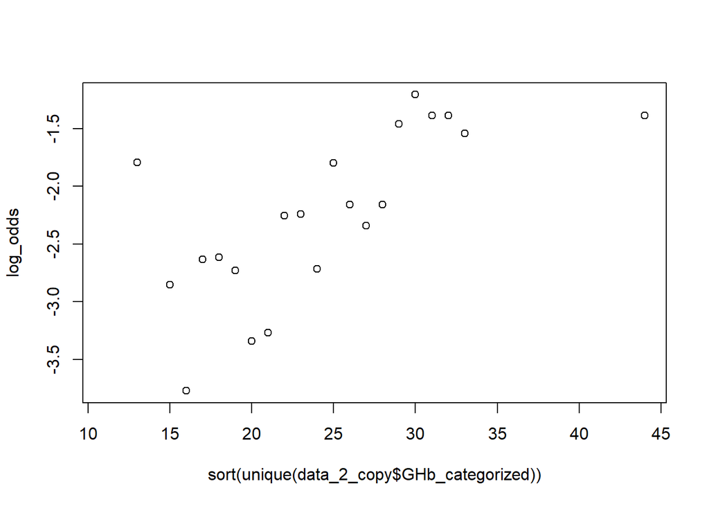

```r
log_odds = log(contingency_table_of_GHb[2,]/(contingency_table_of_GHb[1,]+contingency_table_of_GHb[2,]))
plot(sort(unique(data_2_copy$GHb_categorized)),log_odds)
```

I drawing a scatter plot, and find that GHb have linear with hospitalization log odds , but not square relationship , and we also can use Wald’s test to test relationship

so I think have relationship between hospitalization and GHb , and square term of GHb is not significance so not need add square term of GHb , from plot can know that square term of GHb is not necessary .

```r
unconditional_ligistic = glm(HOSP~HEALTH2+HEALTH3+HEALTH4+GHb_categorized,data = data_2_copy,family='binomial')
summary(unconditional_ligistic)
```

```
##
## Call:
## glm(formula = HOSP ~ HEALTH2 + HEALTH3 + HEALTH4 + GHb_categorized,
##     family = "binomial", data = data_2_copy)
##
## Deviance Residuals:
##     Min       1Q   Median       3Q      Max
## -1.3809  -0.4395  -0.3728  -0.3237   2.5703
##
## Coefficients:
##                 Estimate Std. Error z value Pr(>|z|)
## (Intercept)     -4.29440    0.39809 -10.787  < 2e-16 ***
## HEALTH2          0.42851    0.18220   2.352   0.0187 *
## HEALTH3          1.06757    0.25930   4.117 3.84e-05 ***
## HEALTH4          1.74365    0.57445   3.035   0.0024 **
## GHb_categorized  0.06858    0.01707   4.017 5.89e-05 ***
## ---
## Signif. codes:  0 '***' 0.001 '**' 0.01 '*' 0.05 '.' 0.1 ' ' 1
##
## (Dispersion parameter for binomial family taken to be 1)
##
##     Null deviance: 1231.9  on 2173  degrees of freedom
## Residual deviance: 1186.2  on 2169  degrees of freedom
## AIC: 1196.2
##
## Number of Fisher Scoring iterations: 5
```

```r
conditional_ligistic<-clogit(HOSP~HEALTH2+HEALTH3+HEALTH4+strata(GHb_categorized),data = data_2_copy)
summary(conditional_ligistic)
```

```
## Call:
## coxph(formula = Surv(rep(1, 2174L), HOSP) ~ HEALTH2 + HEALTH3 +
##     HEALTH4 + strata(GHb_categorized), data = data_2_copy, method = "exact")
##
##   n= 2174, number of events= 178
##
##           coef exp(coef) se(coef)     z Pr(>|z|)
## HEALTH2 0.3786    1.4603   0.1854 2.042 0.041138 *
## HEALTH3 0.9804    2.6655   0.2642 3.711 0.000207 ***
## HEALTH4 1.8607    6.4279   0.5923 3.142 0.001680 **
## ---
## Signif. codes:  0 '***' 0.001 '**' 0.01 '*' 0.05 '.' 0.1 ' ' 1
##
##         exp(coef) exp(-coef) lower .95 upper .95
## HEALTH2     1.460     0.6848     1.015     2.100
## HEALTH3     2.666     0.3752     1.588     4.474
## HEALTH4     6.428     0.1556     2.013    20.521
##
## Concordance= 0.583  (se = 0.023 )
## Likelihood ratio test= 18.88  on 3 df,   p=3e-04
## Wald test            = 20.44  on 3 df,   p=1e-04
## Score (logrank) test = 22.08  on 3 df,   p=6e-05
```

I think results is similar from unconditional and conditional logistic regressions , since the coefficient is similar and all p-value are significance

# Q3

```r
data_3 = remove_miss_value(data_3)
data_3 = data_3[,-1]
table_a = table('HIST'=data_3$HIST,'ME'=data_3$ME)
table_a
```

```
##     ME
## HIST   0   1   2
##    0 220  85  63
##    1  14  19  11
```

```r
chisq.test(table_a)
```

```
##
##  Pearson's Chi-squared test
##
## data:  table_a
## X-squared = 13.05, df = 2, p-value = 0.001466
```

most HIST is no (HIST = 0) , and have Mammography Experience is more than no Experience on HIST = 1 , and I use chi-square test find that p-value < 0.05 , so HIST is not independent with ME

2. The likelihood ratio test as for logistic regressions can be used for goodness-of-fit and 2 degrees of freedom

```r
HIST = data_3['HIST']
multires<-multinom(ME~HIST,data=data_3)
multires_NULL<-multinom(ME~1,data=data_3)
summary(multires, Wald=T, cor=T)
```

```
## Call:
## multinom(formula = ME ~ HIST, data = data_3)
##
## Coefficients:
##   (Intercept)     HIST
## 1  -0.9509794 1.256531
## 2  -1.2504803 1.009384
##
## Std. Errors:
##   (Intercept)      HIST
## 1   0.1277115 0.3746633
## 2   0.1428926 0.4275097
##
## Value/SE (Wald statistics):
##   (Intercept)     HIST
## 1   -7.446312 3.353761
## 2   -8.751189 2.361079
##
## Residual Deviance: 792.3399
## AIC: 800.3399
##
## Correlation of Coefficients:
##               1:(Intercept) 1:HIST     2:(Intercept)
## 1:HIST        -0.3408700
## 2:(Intercept)  0.2490796    -0.0849038
## 2:HIST        -0.0832534     0.4743673 -0.3342442
```

```r
diff_deviance = multires_NULL$deviance - multires$deviance
pchisq(diff_deviance, df=2,lower.tail = F)
```

```
## [1] 0.001614001
```

since p-value < 0.05 reject $H_0$(i.e coefficient is not zero)

```r
ME = data_3[,'ME']
data_3b_10<-data_3[ME==1 | ME==0,]
logres_10<-glm(ME~., data = data_3b_10 ,family=binomial)
summary(logres_10)
```

```
##
## Call:
## glm(formula = ME ~ ., family = binomial, data = data_3b_10)
##
## Deviance Residuals:
##     Min       1Q   Median       3Q      Max
## -1.6821  -0.7696  -0.3802   0.9125   2.9833
##
## Coefficients:
##             Estimate Std. Error z value Pr(>|z|)
## (Intercept) -5.70103    1.42420  -4.003 6.26e-05 ***
## SYMPT        0.88396    0.18091   4.886 1.03e-06 ***
## PB          -0.21054    0.07481  -2.814  0.00489 **
## HIST         1.35934    0.44707   3.041  0.00236 **
## BSE          1.41594    0.53719   2.636  0.00839 **
## DETC         0.82096    0.33388   2.459  0.01394 *
## ---
## Signif. codes:  0 '***' 0.001 '**' 0.01 '*' 0.05 '.' 0.1 ' ' 1
##
## (Dispersion parameter for binomial family taken to be 1)
##
##     Null deviance: 417.26  on 337  degrees of freedom
## Residual deviance: 324.01  on 332  degrees of freedom
## AIC: 336.01
##
## Number of Fisher Scoring iterations: 5
```

```r
data_3b_20<-data_3[ME==2 | ME==0,]
data_3b_20[data_3b_20['ME']==2,'ME']=1
logres_20<-glm(ME~., data = data_3b_20 ,family=binomial)
summary(logres_20)
```

```
##
## Call:
## glm(formula = ME ~ ., family = binomial, data = data_3b_20)
##
## Deviance Residuals:
##     Min       1Q   Median       3Q      Max
## -1.3677  -0.7786  -0.5554  -0.2651   2.6052
##
## Coefficients:
##              Estimate Std. Error z value Pr(>|z|)
## (Intercept) -2.555272   1.202531  -2.125  0.03359 *
## SYMPT        0.534684   0.164485   3.251  0.00115 **
## PB          -0.147959   0.073972  -2.000  0.04548 *
## HIST         1.179414   0.452519   2.606  0.00915 **
## BSE          0.970171   0.509394   1.905  0.05684 .
## DETC        -0.007191   0.266006  -0.027  0.97843
## ---
## Signif. codes:  0 '***' 0.001 '**' 0.01 '*' 0.05 '.' 0.1 ' ' 1
##
## (Dispersion parameter for binomial family taken to be 1)
##
##     Null deviance: 339.65  on 307  degrees of freedom
## Residual deviance: 307.84  on 302  degrees of freedom
## AIC: 319.84
##
## Number of Fisher Scoring iterations: 5
```

```r
Q3_c_model = multinom(ME~.,data=data_3)
summary(Q3_c_model)
```

```
## Call:
## multinom(formula = ME ~ ., data = data_3)
##
## Coefficients:
##   (Intercept)     SYMPT         PB     HIST      BSE         DETC
## 1   -5.496143 0.8891653 -0.2122891 1.358564 1.290899  0.784373899
## 2   -2.516515 0.5174552 -0.1465521 1.045293 0.996262 -0.009443492
##
## Std. Errors:
##   (Intercept)     SYMPT         PB      HIST       BSE      DETC
## 1    1.389656 0.1769051 0.07375651 0.4225963 0.5288291 0.3239426
## 2    1.200187 0.1645580 0.07386978 0.4441889 0.5074392 0.2663721
##
## Residual Deviance: 701.3046
## AIC: 725.3046
```

```r
p_value_10 = 2*(1-pnorm(abs(0.784373899/0.3239426)))
p_value_20 = 2*(1-pnorm(abs(-0.009443492/0.2663721)))
cat('ME = 1 vs ME = 0 p-value of DETC is ',p_value_10)
```

```
## ME = 1 vs ME = 0 p-value of DETC is  0.01546357
```

```r
cat('ME = 2 vs ME = 0 p-value of DETC is ',p_value_20)
```

```
## ME = 2 vs ME = 0 p-value of DETC is  0.9717191
```

By Wald tests in (ME = 1 vs ME = 0) is significant , but in (ME = 2 vs ME = 0) is not significant

I guess probable linear assumption not hold

# Repeat (a)-(c) using the proportional odds models

since (a) is not model so is similar original (a)

```r
polrres<-polr(as.factor(ME)~HIST,data=data_3)
summary(polrres, cor=T)
```

```
##
## Re-fitting to get Hessian
```

```
## Call:
## polr(formula = as.factor(ME) ~ HIST, data = data_3)
##
## Coefficients:
##       Value Std. Error t value
## HIST 0.8744     0.2857    3.06
##
## Intercepts:
##     Value   Std. Error t value
## 0|1  0.3769  0.1062     3.5487
## 1|2  1.6469  0.1372    12.0011
##
## Residual Deviance: 795.9915
## AIC: 801.9915
##
## Correlation of Coefficients:
##     HIST   0|1
## 0|1 0.3294
## 1|2 0.3361 0.5802
```

```r
polrres_None<-polr(as.factor(ME)~1,data=data_3)
summary(polrres_None, cor=T)
```

```
##
## Re-fitting to get Hessian
```

```
## Call:
## polr(formula = as.factor(ME) ~ 1, data = data_3)
##
## No coefficients
##
## Intercepts:
##     Value   Std. Error t value
## 0|1  0.2735  0.0995     2.7503
## 1|2  1.5190  0.1283    11.8353
##
## Residual Deviance: 805.198
## AIC: 809.198
##
## Correlation of Coefficients:
## [1] 0.5365
```

```r
diff_deviance = polrres_None$deviance - polrres$deviance
pchisq(diff_deviance, df=2,lower.tail = F)
```

```
## [1] 0.01001925
```

since p-value < 0.05 reject $H_0$(i.e coefficient is not zero)

```r
polrres_Q3_c<-polr(as.factor(ME)~.,data=data_3)
summary(polrres_Q3_c, cor=T)
```

```
##
## Re-fitting to get Hessian
```

```
## Call:
## polr(formula = as.factor(ME) ~ ., data = data_3)
##
## Coefficients:
##         Value Std. Error t value
## SYMPT  0.5756    0.12633  4.5567
## PB    -0.1439    0.05537 -2.5995
## HIST   0.7626    0.29708  2.5669
## BSE    1.0662    0.38309  2.7831
## DETC   0.1979    0.22080  0.8965
##
## Intercepts:
##     Value   Std. Error t value
## 0|1  2.5607  0.9480     2.7013
## 1|2  3.9719  0.9588     4.1427
##
## Residual Deviance: 735.1432
## AIC: 749.1432
##
## Correlation of Coefficients:
##      SYMPT   PB      HIST    BSE     DETC    0|1
## PB    0.1898
## HIST  0.0286  0.0714
## BSE   0.0120  0.0520  0.0093
## DETC -0.1854  0.1982  0.0236 -0.0320
## 0|1   0.3885  0.6518  0.0993  0.3781  0.6328
## 1|2   0.3990  0.6349  0.1098  0.3818  0.6286  0.9912
```

```r
p_value_c = 2*pt(0.8965, df=6,lower.tail = F)
cat('p-value of DETC is ',p_value_c)
```

```
## p-value of DETC is  0.4045179
```

since p-value > 0.05 do not reject $H_0$(i.e not significant for DETC ) , but I think it can not do this ,by Q3 (c) since (ME = 1 vs ME = 0) odds ratio and (ME = 2 vs ME = 0) odds ratio are not same